# Homework 4

Lang Yujian

May 29, 2017

read Data

```r
train <- read.csv("train.csv", stringsAsFactors = FALSE)
train <- train[,-1]
```

Delete the variables with too much NAs and impute Data 1. The missing Data for the BsmtQual, BsmtCond, BsmtExposure, BsmtFinType1, BsmtFinType2 are almost the same amounts. It can be estimated that the missing data in these variables are caused by same reason which might be the absence of the basement. 2. The MasVnrType and MasVnrArea are always NA together. That can caused by the fact that there is no masonry veneer which leads to NA.

```r
dimension <- dim(train)
missingNum <- sapply(train, function(x) {sum(is.na(x))})
data <- train[, missingNum < 0.05 * dimension[1]]
missingNum <- sapply(data, function(x) {sum(is.na(x))})
data$BsmtExposure[which(is.na(data$BsmtExposure))] <- 'None'
data$BsmtFinType1[which(is.na(data$BsmtFinType1))] <- 'None'
data$BsmtFinType2[which(is.na(data$BsmtFinType2))] <- 'None'
data$BsmtQual[which(is.na(data$BsmtQual))] <- 'None'
data$BsmtCond[which(is.na(data$BsmtCond))] <- 'None'
missingNum <- sapply(data, function(x) {sum(is.na(x))})
```

```r
library(mice)
data$MasVnrType[which(is.na(data$MasVnrArea))] <- "None"
data$MasVnrArea[which(is.na(data$MasVnrArea))] <- 0
data$Electrical <- as.factor(data$Electrical)
data_complete <- mice(data, m = 1, printFlag = FALSE)
data_complete <- complete(data_complete)
```

Make sure there are no missing values inside.

```r
TotalMissingSum <- sum(sapply(data_complete, function(x) {sum(is.na(x))}))
```

Add the new features 1. Basement Square Feet(Type I and Type II) 2. 1st and 2nd Floor Square Feet 3. Wood Deck and Open Porch Square Feet 4. Basement Bathroom 5. Bathroom 6. Age of house (Year - YearBuilt) 7. Year of Last Remodel 8. High Quality Square Feet 9. Total Area

```r
data_complete$BasementSF <- data_complete$BsmtFinSF1 + data_complete$BsmtFinSF2
data_complete$OneandTwoFloorSF <- data_complete$X1stFlrSF + data_complete$X2ndFlrSF
data_complete$FrontSF <- data_complete$WoodDeckSF + data_complete$OpenPorchSF
data_complete$BasementBath <- data_complete$BsmtFullBath + 0.5 * data_complete$BsmtHalfBath
data_complete$Bath <- data_complete$FullBath + 0.5 * data_complete$HalfBath
data_complete$Age <- data_complete$YrSold - data_complete$YearBuilt
data_complete$YrOfRemodel <- data_complete$YrSold - data_complete$YearRemodAdd
data_complete$HighQualSF <- data_complete$BsmtFinSF1 + data_complete$BsmtFinSF2 + data_complete$GrLivArea + data_complete$GarageArea + data_complete$WoodDeckSF + data_complete$OpenPorchSF
data_complete$TotalArea <- data_complete$GrLivArea+data_complete$TotalBsmtSF+data_complete$GarageArea+data_complete $LotArea+data_complete$MasVnrArea+data_complete$OpenPorchSF+data_complete$PoolArea+data_complete$ScreenPorch+data_complete$WoodDeckSF+data_complete$X3SsnPorch+data_complete$EnclosedPorch
data_complete$LogPrice <- log(data_complete$SalePrice)
data_complete <- data_complete[,-69] #get rid of SalePrice
```

Save the imputed data as future use

```r
write.csv(data_complete, file = "data_complete.csv", row.names = FALSE)
```

PreProcess Test Dataset and Impute test dataset 1. Exterior1st and Exterior2nd are NA all together, so the reason for the missing data is that there is no covering for the house 2. MasVnrType and MasVnrArea are most of the times, NA together. This is probably caused by the fact that the masonry veneer is none

```r
test <- read.csv("test.csv", stringsAsFactors = FALSE)
id <- test$Id
test <- test[,-1]
all_names <- colnames(data)
testdata <- test[,-c(3,6,57,58, 59, 60, 63,64,72, 73, 74)]
sapply(testdata, function(x) {sum(is.na(x))})
```

```
##    MSSubClass      MSZoning       LotArea        Street      LotShape
##             0             4             0             0             0
##   LandContour     Utilities     LotConfig     LandSlope  Neighborhood
##             0             2             0             0             0
##    Condition1    Condition2      BldgType    HouseStyle   OverallQual
##             0             0             0             0             0
##   OverallCond     YearBuilt  YearRemodAdd     RoofStyle      RoofMatl
##             0             0             0             0             0
##   Exterior1st   Exterior2nd    MasVnrType    MasVnrArea     ExterQual
##             1             1            16            15             0
##     ExterCond    Foundation      BsmtQual      BsmtCond  BsmtExposure
##             0             0            44            45            44
##  BsmtFinType1    BsmtFinSF1  BsmtFinType2    BsmtFinSF2     BsmtUnfSF
##            42             1            42             1             1
##   TotalBsmtSF       Heating     HeatingQC    CentralAir    Electrical
##             1             0             0             0             0
##     X1stFlrSF     X2ndFlrSF  LowQualFinSF     GrLivArea  BsmtFullBath
##             0             0             0             0             2
##  BsmtHalfBath      FullBath      HalfBath  BedroomAbvGr  KitchenAbvGr
##             2             0             0             0             0
##   KitchenQual  TotRmsAbvGrd    Functional    Fireplaces    GarageCars
##             1             0             2             0             1
##    GarageArea    PavedDrive    WoodDeckSF   OpenPorchSF EnclosedPorch
##             1             0             0             0             0
##    X3SsnPorch   ScreenPorch      PoolArea       MiscVal        MoSold
##             0             0             0             0             0
##        YrSold      SaleType SaleCondition
##             0             1             0
```

```r
testdata[c(28, 889), "BsmtExposure"] <- 'Unf'
testdata[c(758, 759), "BsmtQual"] <- 'None'
testdata$BsmtFinType1[which(is.na(testdata$BsmtExposure))] <- 'None'
testdata$BsmtFinType2[which(is.na(testdata$BsmtExposure))] <- 'None'
testdata$BsmtQual[which(is.na(testdata$BsmtExposure))] <- 'None'
testdata$BsmtCond[which(is.na(testdata$BsmtExposure))] <- 'None'
testdata$BsmtFinSF1[which(is.na(testdata$BsmtExposure))] <- 0
testdata$BsmtFinSF2[which(is.na(testdata$BsmtExposure))] <- 0
testdata$BsmtUnfSF[which(is.na(testdata$BsmtExposure))] <- 0
testdata$BsmtExposure[which(is.na(testdata$BsmtExposure))] <- 'None'
testdata$MSZoning = as.factor(testdata$MSZoning)
testdata$Exterior1st[which(is.na(testdata$Exterior1st))] <- 'None'
testdata$Exterior2nd[which(is.na(testdata$Exterior2nd))] <- 'None'
testdata$MasVnrType[which(is.na(testdata$MasVnrArea))] <- 'None'
testdata$MasVnrArea[which(is.na(testdata$MasVnrArea))] <- 0
testdata$MasVnrType = as.factor(testdata$MasVnrType)
testdata$KitchenQual = as.factor(testdata$KitchenQual)
testdata$Functional = as.factor(testdata$Functional)
testdata$SaleType = as.factor(testdata$SaleType)
testdata$BsmtCond = as.factor(testdata$BsmtCond)
testdata$Utilities[which(is.na(testdata$Utilities))] = 'AllPub'
test_complete <- mice(testdata, m = 1, method = 'cart', printFlag = FALSE)
test_complete <- complete(test_complete)
TotalMissingNum <- sum(sapply(test_complete, function(x) {sum(is.na(x))}))
```

Add New Features into the test dataset

```r
test_complete$BasementSF <- test_complete$BsmtFinSF1 + test_complete$BsmtFinSF2
test_complete$OneandTwoFloorSF <- test_complete$X1stFlrSF + test_complete$X2ndFlrSF
test_complete$FrontSF <- test_complete$WoodDeckSF + test_complete$OpenPorchSF
test_complete$BasementBath <- test_complete$BsmtFullBath + 0.5 * test_complete$BsmtHalfBath
test_complete$Bath <- test_complete$FullBath + 0.5 * test_complete$HalfBath
test_complete$Age <- test_complete$YrSold - test_complete$YearBuilt
test_complete$YrOfRemodel <- test_complete$YrSold - test_complete$YearRemodAdd
test_complete$HighQualSF <- test_complete$BsmtFinSF1 + test_complete$BsmtFinSF2 + test_complete$GrLivArea + test_complete$GarageArea + test_complete$WoodDeckSF + test_complete$OpenPorchSF
test_complete$TotalArea <- test_complete$GrLivArea+test_complete$TotalBsmtSF+test_complete$GarageArea+test_complete$LotArea+test_complete$MasVnrArea+test_complete$OpenPorchSF+test_complete$PoolArea+test_complete$ScreenPorch+test_complete$WoodDeckSF+test_complete$X3SsnPorch+test_complete$EnclosedPorch
write.csv(test_complete, file = 'test_complete.csv', row.names = FALSE)
```

Read the imputed data

```r
train_complete <- read.csv("data_complete.csv", header = TRUE)
test_complete <- read.csv("test_complete.csv", header = TRUE)
LogPrice = train_complete$LogPrice
complete = rbind(train_complete[,-78], test_complete)
for (i in 1:dim(complete)[2]) {
  if (is.character(complete[,i])) {
    complete[,i] = as.factor(complete[,i])
  }
}
train_complete = complete[1:1460,]
train_complete = cbind(train_complete, LogPrice)
test_complete = complete[1461:2919,]
train.missing = sum(sapply(train_complete, function(x){sum(is.na(x))}))
test.missing = sum(sapply(test_complete, function(x){sum(is.na(x))}))
```

Decision Tree

```r
set.seed(1)
formula <- paste('LogPrice ~ .-LogPrice')
library(rpart)
train.ind <- sample(1:dim(train_complete)[1], dim(train_complete)[1] * 0.7)
train.data <- train_complete[train.ind, ]
test.data <- train_complete[-train.ind, ]
dt <- rpart(formula, method = 'anova', data = train.data, control = rpart.control(cp = 0))
best.cp <- dt$cptable[which.min(dt$cptable[,'xerror']), 'CP']
cptab <- as.data.frame(dt$cptable)
tradeoff.cp <- cptab$CP[min(which(cptab$xerror - cptab$xstd < min(cptab$xerror)))]
"cp value for lowest xerror"
```

```
## [1] "cp value for lowest xerror"
```

```r
best.cp
```

```
## [1] 0.0006222398
```

```r
"lowest cp value for acceptable xerror (1 standard deviation)"
```

```
## [1] "lowest cp value for acceptable xerror (1 standard deviation)"
```

```r
tradeoff.cp
```

```
## [1] 0.002775229
```

```r
tree.pruned <- prune(dt, cp = tradeoff.cp)
test.pred <- predict(tree.pruned, test.data)
```

Show predicted error for test.data and Save the Predicted Result for test.csv

```r
"mean sum square error for the decision tree model"
```

```
## [1] "mean sum square error for the decision tree model"
```

```r
sum((test.pred - test.data$LogPrice)^2) / (dim(test.data)[1])
```

```
## [1] 0.03760601
```

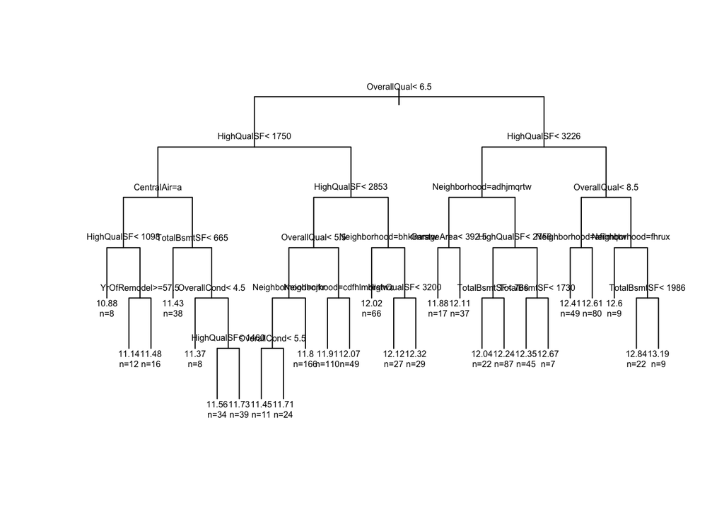

```r
dt.pred <- exp(predict(tree.pruned, test_complete))
dt.result <- data.frame(cbind(1461:2919, dt.pred))
colnames(dt.result) <- c('Id', 'SalePrice')
write.csv(dt.result, "dt_result.csv", row.names = FALSE)
plot(tree.pruned, uniform = TRUE)
# Since labels often extend outside the plot region it can be helpful to specify xpd = TRUE
text(tree.pruned, cex = 0.5, use.n = TRUE, xpd = TRUE)
```

Random Forest

```r
set.seed(2)
library(randomForest)
```

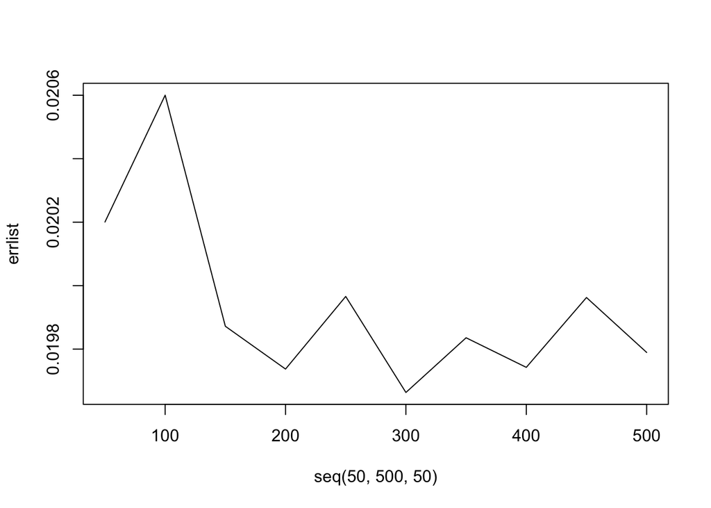

```r
formula <- paste("LogPrice ~ .-LogPrice")
train.ind <- sample(1:dim(train_complete)[1], dim(train_complete)[1] * 0.7)
train.data <- train_complete[train.ind, ]
test.data <- train_complete[-train.ind, ]
errlist <- NULL
for (i in seq(50, 500, 50)) {
  rf <- randomForest(as.formula(formula), data = train.data, importance = TRUE, ntree = i)
  test.pred <- predict(rf, test.data)
  errlist <- c(errlist, sum((test.pred - test.data$LogPrice)^2) / (dim(test.data)[1]))
}
plot(seq(50, 500, 50), errlist, type = 'l')
```

Show the predicted stats for the trained random forest model

```r
rf <- randomForest(as.formula(formula), data = train.data, importance = TRUE, ntree = 300)
test.pred <- predict(rf, test.data)
"mean sum square error for the random forest model"
```

```
## [1] "mean sum square error for the random forest model"
```

```r
sum((test.pred - test.data$LogPrice)^2) / (dim(test.data)[1])
```

```
## [1] 0.01974815
```

```r
rf.pred <- exp(predict(rf, test_complete))
rf.result <- data.frame(cbind(1461:2919, rf.pred))
colnames(rf.result) <- c('Id', 'SalePrice')
write.csv(rf.result, "rf_result.csv", row.names = FALSE)
```

Boosting Tree, prepare the train.data and test.data for training and evaluation process

```r
set.seed(3)
library(xgboost)
formula <- paste("LogPrice ~ .-LogPrice")
complete.matrix <- model.matrix(~., data = complete)
train.matrix <- complete.matrix[1:1460,]
test.matrix <- complete.matrix[1461:2919,]
train.ind <- sample(1:dim(train.matrix)[1], dim(train.matrix)[1] * 0.7)
train.data <- train.matrix[train.ind, ]
train.logprice <- LogPrice[train.ind]
test.data <- train.matrix[-train.ind, ]
test.logprice <- LogPrice[-train.ind]
```

Fix the eta (learning rate) to be 0.1 and find the optimal nrounds (number of estimators) using the metrics rmse

```r
set.seed(3)
param <- list(eta = 0.1, max_depth = 5, min_child_weight = 1, gamma = 0, subsample = 0.8,
              colsample_bytree = 0.8, objective = 'reg:linear', nthread = 6, scale_pos_weight = 1)
cvresult <- xgb.cv(data = train.data, label = train.logprice, params = param, nfold = 5,
                   nrounds = 500, verbose = F, maximize = FALSE)
nrounds_best <- which.min(cvresult$evaluation_log$test_rmse_mean)
nrounds_tradeoff <- min(which(cvresult$evaluation_log$test_rmse_mean - cvresult$evaluation_log$test_rmse_std < min(cvresult$evaluation_log$test_rmse_mean)))
'best nrounds'
```

```
## [1] "best nrounds"
```

```r
nrounds_best
```

```
## [1] 347
```

```r
'tradeoff nrounds'
```

```
## [1] "tradeoff nrounds"
```

```r
nrounds_tradeoff
```

```
## [1] 57
```

```r
set.seed(3)
nrounds <- 1000
df <- data.frame('depth' = integer(0), 'child_weight' = integer(0), 'best_id' = integer(0), 'best_train_rmse' = integer(0))
for (depth in seq(3, 15, 2)) {
  for (child_weight in 1:6) {
    param <- list(eta = 0.1, gamma = 0, subsample = 0.8, colsample_bytree = 0.8, objective = 'reg:linear',
              nthread = 6, scale_pos_weight = 1, max_depth = depth, min_child_weight = child_weight)
    cvresult <- xgb.cv(data = train.data, label = train.logprice, params = param, nfold = 5, nrounds = nrounds, verbose = F, maximize = FALSE)
    bestid <- which.min(cvresult$evaluation_log$test_rmse_mean)
    df <- rbind(df, c(depth, child_weight, bestid, cvresult$evaluation_log$test_rmse_mean[bestid]))
  }
}
colnames(df) <- c('depth', 'child_weight', 'best_id', 'best_train_rmse')
"All results:"
```

```
## [1] "All results:"
```

```r
df
```

```
##    depth child_weight best_id best_train_rmse
## 1      3            1     223       0.1432260
## 2      3            2     162       0.1422644
## 3      3            3     198       0.1365080
## 4      3            4     237       0.1423898
## 5      3            5     203       0.1386916
## 6      3            6     195       0.1438634
## 7      5            1     265       0.1453406
## 8      5            2     261       0.1418946
## 9      5            3     125       0.1410672
## 10     5            4     164       0.1359010
## 11     5            5     171       0.1350022
## 12     5            6     392       0.1382962
## 13     7            1     157       0.1429940
## 14     7            2     231       0.1412012
```

[output cut: 28 more lines]

```r
"Best result:"
```

```
## [1] "Best result:"
```

```r
df[which.min(df$best_train_rmse),]
```

```
##    depth child_weight best_id best_train_rmse
## 30    11            6     945       0.1338522
```

Set depth to be 11, child_weight to be 6. Tune Gamma

```r
set.seed(3)
nrounds <- 2000
df <- data.frame('gamma' = double(0), 'best_id' = integer(0), 'best_train_rmse' = integer(0))
for (gamma in seq(0,0.5,0.05)) {
  param <- list(eta = 0.1, gamma = gamma, subsample = 0.8, colsample_bytree = 0.8, objective = 'reg:linear',
              nthread = 6, scale_pos_weight = 1, max_depth = 11, min_child_weight = 6)
    cvresult <- xgb.cv(data = train.data, label = train.logprice, params = param, nfold = 5, nrounds = nrounds, verbose = F, maximize = FALSE)
    bestid <- which.min(cvresult$evaluation_log$test_rmse_mean)
    df <- rbind(df, c(gamma, bestid, cvresult$evaluation_log$test_rmse_mean[bestid]))
}
colnames(df) <- c('gamma', 'bestid', 'best_train_rmse')
"All results:"
```

```
## [1] "All results:"
```

```r
df
```

```
##    gamma bestid best_train_rmse
## 1   0.00   1075       0.1448068
## 2   0.05    358       0.1405952
## 3   0.10   1672       0.1439234
## 4   0.15   1866       0.1399216
## 5   0.20    987       0.1442612
## 6   0.25   1898       0.1469518
## 7   0.30   1343       0.1490980
## 8   0.35   1962       0.1521954
## 9   0.40   1954       0.1531554
## 10  0.45   1912       0.1541772
## 11  0.50   1565       0.1546062
```

```r
"Best result:"
```

```
## [1] "Best result:"
```

```r
df[which.min(df$best_train_rmse),]
```

```
##   gamma bestid best_train_rmse
## 4  0.15   1866       0.1399216
```

Set Gamma to be 0.15. Tune subsample and colsample_bytree

```r
set.seed(3)
nrounds <- 2000
df <- data.frame('subsample' = double(0), 'colsample_bytree' = double(0), 'best_id' = integer(0), 'best_train_rmse' = integer(0))
for (subsample in seq(0.6,1.0,0.1)) {
  for (colsample_bytree in seq(0.6, 1.0, 0.1)) {
    param <- list(eta = 0.1, gamma = 0.15, subsample = subsample, colsample_bytree = colsample_bytree, objective = 'reg:linear',
              nthread = 6, scale_pos_weight = 1, max_depth = 11, min_child_weight = 6)
      cvresult <- xgb.cv(data = train.data, label = train.logprice, params = param, nfold = 5, nrounds = nrounds, verbose = F, maximize = FALSE)
      bestid <- which.min(cvresult$evaluation_log$test_rmse_mean)
      df <- rbind(df, c(subsample, colsample_bytree, bestid, cvresult$evaluation_log$test_rmse_mean[bestid]))
  }
}
colnames(df) <- c('subsample', 'colsample_bytree', 'best_id', 'best_train_rmse')
"All results:"
```

```
## [1] "All results:"
```

```r
df
```

```
##    subsample colsample_bytree best_id best_train_rmse
## 1        0.6              0.6    1836       0.1730352
## 2        0.6              0.7    1917       0.1545836
## 3        0.6              0.8    1988       0.1439228
## 4        0.6              0.9    1785       0.1357480
## 5        0.6              1.0     448       0.1378462
## 6        0.7              0.6     916       0.1753188
## 7        0.7              0.7    1854       0.1588764
## 8        0.7              0.8    1965       0.1448242
## 9        0.7              0.9    1987       0.1388144
## 10       0.7              1.0    1860       0.1375676
## 11       0.8              0.6    1995       0.1714052
## 12       0.8              0.7    1944       0.1562874
## 13       0.8              0.8    1994       0.1440414
## 14       0.8              0.9    1989       0.1365368
## 15       0.8              1.0    1908       0.1399568
## 16       0.9              0.6     235       0.1773670
## 17       0.9              0.7    1876       0.1550696
## 18       0.9              0.8    1914       0.1424868
## 19       0.9              0.9    1843       0.1458464
## 20       0.9              1.0    1982       0.1371542
## 21       1.0              0.6     122       0.1791662
## 22       1.0              0.7     137       0.1637842
## 23       1.0              0.8      96       0.1502036
## 24       1.0              0.9      98       0.1460854
## 25       1.0              1.0      80       0.1439454
```

```r
"Best result:"
```

```
## [1] "Best result:"
```

```r
df[which.min(df$best_train_rmse),]
```

```
##   subsample colsample_bytree best_id best_train_rmse
## 4       0.6              0.9    1785        0.135748
```

Set subsample to be 0.6, colsample_bytree to be 0.9. Tune the regularization parameters (alpha) Find the range for alpha

```r
set.seed(3)
nrounds <- 2000
df <- data.frame('alpha' = double(0), 'best_id' = integer(0), 'best_train_rmse' = integer(0))
for (alpha in c(0, 0.00001, 0.0001, 0.001, 0.01, 0.1, 1, 100)) {
    param <- list(eta = 0.1, gamma = 0.15, subsample = 0.6, colsample_bytree = 0.9, objective = 'reg:linear',
              nthread = 6, scale_pos_weight = 1, max_depth = 11, min_child_weight = 6, alpha = alpha)
    cvresult <- xgb.cv(data = train.data, label = train.logprice, params = param, nfold = 5, nrounds = nrounds, verbose = F, maximize = FALSE)
    bestid <- which.min(cvresult$evaluation_log$test_rmse_mean)
    df <- rbind(df, c(alpha, bestid, cvresult$evaluation_log$test_rmse_mean[bestid]))
}
colnames(df) <- c('alpha', 'best_id', 'best_train_rmse')
"All results:"
```

```
## [1] "All results:"
```

```r
df
```

```
##   alpha best_id best_train_rmse
## 1 0e+00    2000       0.1391416
## 2 1e-05    1973       0.1377664
## 3 1e-04    1873       0.1364674
## 4 1e-03    1992       0.1366548
## 5 1e-02    1968       0.1378808
## 6 1e-01    1854       0.1368298
## 7 1e+00    1618       0.1443392
## 8 1e+02    1944       0.3580354
```

```r
"Best result:"
```

```
## [1] "Best result:"
```

```r
df[which.min(df$best_train_rmse),]
```

```
##   alpha best_id best_train_rmse
## 3 1e-04    1873       0.1364674
```

Find alpha

```r
set.seed(3)
nrounds <- 2000
df <- data.frame('alpha' = double(0), 'best_id' = integer(0), 'best_train_rmse' = integer(0))
for (alpha in c(0.0004, 0.0005, 0.0006, 0.0007, 0.0008, 0.0009)) {
    param <- list(eta = 0.1, gamma = 0.15, subsample = 0.6, colsample_bytree = 0.9, objective = 'reg:linear',
              nthread = 6, scale_pos_weight = 1, max_depth = 11, min_child_weight = 6, alpha = alpha)
    cvresult <- xgb.cv(data = train.data, label = train.logprice, params = param, nfold = 5, nrounds = nrounds, verbose = F, maximize = FALSE)
    bestid <- which.min(cvresult$evaluation_log$test_rmse_mean)
    df <- rbind(df, c(alpha, bestid, cvresult$evaluation_log$test_rmse_mean[bestid]))
}
colnames(df) <- c('alpha', 'best_id', 'best_train_rmse')
"All results:"
```

```
## [1] "All results:"
```

```r
df
```

```
##   alpha best_id best_train_rmse
## 1 4e-04    1232       0.1400284
## 2 5e-04    1973       0.1374522
## 3 6e-04    1948       0.1373432
## 4 7e-04    1993       0.1366120
## 5 8e-04    1973       0.1385936
## 6 9e-04    1985       0.1367582
```

```r
"Best result:"
```

```
## [1] "Best result:"
```

```r
df[which.min(df$best_train_rmse),]
```

```
##   alpha best_id best_train_rmse
## 4 7e-04    1993        0.136612
```

Set alpha to be 0.0007 Tune regularization parameter (lambda) Find range for lambda

```r
set.seed(3)
nrounds <- 2000
df <- data.frame('lambda' = double(0), 'best_id' = integer(0), 'best_train_rmse' = integer(0))
for (lambda in c(0, 0.00001, 0.00001, 0.0001, 0.001, 0.01, 0.1, 1, 100)) {
    param <- list(eta = 0.1, gamma = 0.15, subsample = 0.6, colsample_bytree = 0.9, objective = 'reg:linear',
              nthread = 6, scale_pos_weight = 1, max_depth = 11, min_child_weight = 6, alpha = 0.0007, lambda = lambda)
    cvresult <- xgb.cv(data = train.data, label = train.logprice, params = param, nfold = 5, nrounds = nrounds, verbose = F, maximize = FALSE)
    bestid <- which.min(cvresult$evaluation_log$test_rmse_mean)
    df <- rbind(df, c(lambda, bestid, cvresult$evaluation_log$test_rmse_mean[bestid]))
}
colnames(df) <- c('lambda', 'best_id', 'best_train_rmse')
"All results:"
```

```
## [1] "All results:"
```

```r
df
```

```
##   lambda best_id best_train_rmse
## 1  0e+00    1633       0.1422912
## 2  1e-05    1017       0.1424746
## 3  1e-05    1849       0.1422860
## 4  1e-04    1568       0.1395708
## 5  1e-03    1878       0.1425696
## 6  1e-02    1284       0.1383090
## 7  1e-01    1970       0.1379762
## 8  1e+00    1912       0.1393240
## 9  1e+02    1926       0.1479838
```

```r
"Best result:"
```

```
## [1] "Best result:"
```

```r
df[which.min(df$best_train_rmse),]
```

```
##   lambda best_id best_train_rmse
## 7    0.1    1970       0.1379762
```

Find lambda

```r
set.seed(3)
nrounds <- 2000
df <- data.frame('lambda' = double(0), 'best_id' = integer(0), 'best_train_rmse' = integer(0))
for (lambda in c(0.5, 0.6, 0.7, 0.8, 0.9)) {
    param <- list(eta = 0.1, gamma = 0.15, subsample = 0.6, colsample_bytree = 0.9, objective = 'reg:linear',
              nthread = 6, scale_pos_weight = 1, max_depth = 11, min_child_weight = 6, alpha = 0.0007, lambda = lambda)
    cvresult <- xgb.cv(data = train.data, label = train.logprice, params = param, nfold = 5, nrounds = nrounds, verbose = F, maximize = FALSE)
    bestid <- which.min(cvresult$evaluation_log$test_rmse_mean)
    df <- rbind(df, c(lambda, bestid, cvresult$evaluation_log$test_rmse_mean[bestid]))
}
colnames(df) <- c('lambda', 'best_id', 'best_train_rmse')
"All results:"
```

```
## [1] "All results:"
```

```r
df
```

```
##   lambda best_id best_train_rmse
## 1    0.5    1926       0.1398074
## 2    0.6    1582       0.1369266
## 3    0.7    1957       0.1394488
## 4    0.8    1992       0.1358774
## 5    0.9    1994       0.1394424
```

```r
"Best result:"
```

```
## [1] "Best result:"
```

```r
df[which.min(df$best_train_rmse),]
```

```
##   lambda best_id best_train_rmse
## 4    0.8    1992       0.1358774
```

Set lambda to be 0.8. Tune learning rate (eta) Find range for eta

```r
set.seed(3)
nrounds <- 5000
df <- data.frame('eta' = double(0), 'best_id' = integer(0), 'best_train_rmse' = integer(0))
for (eta in c(0.001, 0.01, 0.1, 0.2, 0.3)) {
    param <- list(eta = eta, gamma = 0.15, subsample = 0.6, colsample_bytree = 0.9, objective = 'reg:linear',
              nthread = 6, scale_pos_weight = 1, max_depth = 11, min_child_weight = 6, alpha = 0.0007, lambda = 0.8)
    cvresult <- xgb.cv(data = train.data, label = train.logprice, params = param, nfold = 5, nrounds = nrounds, verbose = F, maximize = FALSE)
    bestid <- which.min(cvresult$evaluation_log$test_rmse_mean)
    df <- rbind(df, c(eta, bestid, cvresult$evaluation_log$test_rmse_mean[bestid]))
}
colnames(df) <- c('eta', 'best_id', 'best_train_rmse')
"All results:"
```

```
## [1] "All results:"
```

```r
df
```

```
##     eta best_id best_train_rmse
## 1 0.001    5000       0.1678202
## 2 0.010    4946       0.1356112
## 3 0.100    4942       0.1398146
## 4 0.200     425       0.1440112
## 5 0.300    1962       0.1528314
```

```r
"Best result:"
```

```
## [1] "Best result:"
```

```r
df[which.min(df$best_train_rmse),]
```

```
##    eta best_id best_train_rmse
## 2 0.01    4946       0.1356112
```

Find eta

```r
set.seed(3)
nrounds <- 5000
df <- data.frame('eta' = double(0), 'best_id' = integer(0), 'best_train_rmse' = integer(0))
for (eta in c(0.01, 0.02, 0.03, 0.04)) {
    param <- list(eta = eta, gamma = 0.15, subsample = 0.6, colsample_bytree = 0.9, objective = 'reg:linear',
              nthread = 6, scale_pos_weight = 1, max_depth = 11, min_child_weight = 6, alpha = 0.0007, lambda = 0.8)
    cvresult <- xgb.cv(data = train.data, label = train.logprice, params = param, nfold = 5, nrounds = nrounds, verbose = F, maximize = FALSE)
    bestid <- which.min(cvresult$evaluation_log$test_rmse_mean)
    df <- rbind(df, c(eta, bestid, cvresult$evaluation_log$test_rmse_mean[bestid]))
}
colnames(df) <- c('eta', 'best_id', 'best_train_rmse')
"All results:"
```

```
## [1] "All results:"
```

```r
df
```

```
##    eta best_id best_train_rmse
## 1 0.01    4989       0.1373264
## 2 0.02    4948       0.1360340
## 3 0.03    4322       0.1348900
## 4 0.04    4860       0.1370534
```

```r
"Best result:"
```

```
## [1] "Best result:"
```

```r
df[which.min(df$best_train_rmse),]
```

```
##    eta best_id best_train_rmse
## 3 0.03    4322         0.13489
```

The final paramter set

```r
set.seed(3)
nrounds <- 4322
param <- list(eta = 0.03, gamma = 0.15, subsample = 0.6, colsample_bytree = 0.9, objective = 'reg:linear',
              nthread = 6, scale_pos_weight = 1, max_depth = 11, min_child_weight = 6, alpha = 0.0007, lambda = 0.8)
```

Compare with the performance with default parameter set

```r
set.seed(3)
cvresult <- xgb.cv(data = train.data, label = train.logprice, params = param, nfold = 5, nrounds = nrounds, verbose = F, maximize = FALSE)
"tuned parameter set test rmse"
```

```
## [1] "tuned parameter set test rmse"
```

```r
cvresult$evaluation_log$test_rmse_mean[nrounds]
```

```
## [1] 0.1370954
```

```r
defaultcv <- xgb.cv(data = train.data, label = train.logprice, nfold = 5, nrounds = nrounds, verbose = F, maximize = F)
"default parameter set test rmse"
```

```
## [1] "default parameter set test rmse"
```

```r
defaultcv$evaluation_log$test_rmse_mean[nrounds]
```

```
## [1] 0.1542904
```

It can be concluded that the tunned parameter set have better performance than the default parameter set

```r
set.seed(3)
gbt <- xgboost(data = train.data, label = train.logprice, nrounds = nrounds, params = param, verbose = F, maximize = F)
test.pred <- predict(gbt, test.data)
"mean sum square error for the boosting tree model"
```

```
## [1] "mean sum square error for the boosting tree model"
```

```r
sum((test.pred - test.logprice)^2) / (dim(test.data)[1])
```

```
## [1] 0.01463133
```

Compare result from decision tree, random forest, gradient boosting tree

```r
result <- cbind(c("decision tree", "random forest", "gradient boosting tree"), c(0.03760601, 0.01974815, 0.01463133))
colnames(result) <- c("method", "mean sum square error")
result
```

```
##      method                   mean sum square error
## [1,] "decision tree"          "0.03760601"
## [2,] "random forest"          "0.01974815"
## [3,] "gradient boosting tree" "0.01463133"
```

It can be seen that from the performance perspective, decision tree < random forest < gradient boosting tree predict the SalePrice for test.csv

```r
gbt.pred <- exp(predict(gbt, test.matrix))
gbt.result <- data.frame(cbind(1461:2919, gbt.pred))
colnames(gbt.result) <- c('Id', 'SalePrice')
write.csv(gbt.result, "gbt_result.csv", row.names = FALSE)
```